# Dey Sarkar_Arnab_HW_06

## CMPINF 2100: Homework 06

## Assigned: Tuesday of Week 06 at 11:00PM

## DUE: Tuesday of Week 07 at 11:59PM

## Overview

This assignment is open ended similar to the previous assignment. You will work with the SAME three data sets as in Homework 05. You already identified the BASIC and ESSENTIAL information for the variables (columns) in the three data sets. You calculated important summary statistics, and even examined if summary statistics changed based on different grouping variables. The Homework 05 exploration results were displayed within DataFrames and/or text. You printed results to the screen and provided Markdown text to accompany the table-like results.

You will repeat many of the same exploration steps from Homework 05, but this time you will **visually** explore the data! You will graphically display the exploratory results using plots/figures. You will explore **marginal** behavior by focusing on individual variables. Then you will explore **combinations** and **relationships** between 2 variables. The figures associated with studying **relationships** will graphically answer the SPLIT-APPLY-COMBINE related questions from the previous assignment. Certain tasks allow you to choose between Pandas plotting methods and Seaborn functions, while others state you must use Seaborn to create the figures.

The last question requires you to start visually exploring **marginal** behavior associated with one of the final projects of your choosing.

**You must use the 3 data sets provided in Homework 05 Canvas assignment page. You may use the same data you previously downloaded, or redownload the CSV files to the appropriate directory on your computer.**

## Required tasks for Problem 01 through 03

For each of the 3 assigned data sets you must create plots/figures/charts to explore **marginal** behavior. You must therefore perform the following tasks:

- Create BAR CHARTS to visually show the counts for the number of rows per unique value for NON-NUMERIC columns
  - You may use Pandas or Seaborn to create the bar charts
- Create HISTOGRAMS to visually show the DISTRIBUTION of NUMERIC columns
  - You may use Pandas or Seaborn to create the histogram
- **IMPORTANT:** You **MUST** visually explore the counts of NUMERIC columns that have less than 20 unique values as if they are NON-NUMERIC columns
- **IMPORTANT:** After creating BAR CHARTS and HISTOGRAMS answer the following:
  - Do the categories of the NON-NUMERIC columns have similar counts?
  - Do the histograms of the NUMERIC columns look roughly like bell curves?

For each of the 3 assigned data sets you must create plots/figures/charts to explore **combinations** between 2 NON-NUMERIC columns. You must therefore perform the following tasks:

- Create DODGED bar charts to visually show the COUNTS for COMBINATIONS between 2 NON-NUMERIC columns
  - You **MUST** create the DODGED bar chart using Seaborn
- Create HEAT MAPS to visually show the COUNTS for COMBINATIONS between 2 NON-NUMERIC columns
  - You **MUST** create the HEAT MAP using Seaborn
  - The HEAT MAP **MUST** be annotated with count displayed as TEXT
- **IMPORTANT:** You **MUST** treat NUMERIC columns that have less than 20 unique values as if they are NON-NUMERIC columns
- **IMPORTANT:** After creating the DODGED bar charts and HEAT MAPS answer the following:
  - Are there combinations between the 2 variables NOT present in the data?
  - Which plot type was it easier to identify combinations that were NOT present?

For each of the 3 assigned data sets you must create plots/figures/charts to explore **relationships** between CATEGORICAL and CONTINUOUS variables. You must therefore explore the relationship between 1 NON-NUMERIC column and 1 NUMERIC column. You must perform the following tasks:

- Create CONDITIONAL KDE plots to show the conditional distribution of the NUMERIC column CONDITIONED ON (or GROUPED BY) the NON-NUMERIC column
  - You **MUST** create the CONDITIONAL KDE plot using Seaborn with the NON-NUMERIC column associated with the KDE COLOR
  - You **MUST** remove the SAMPLE SIZE issue with the CONDITIONAL KDE plot
- Create BOXPLOTS to show if the SUMMARY STATISTICS of the NUMERIC column CHANGE across the CATEGORIES of the NON-NUMERIC column
  - You **MUST** create the BOXPLOT using Seaborn
- Create POINT PLOTS to show if the CONDITIONAL MEAN of the NUMERIC columns CHANGE across the CATEGORIES of the NON-NUMERIC column
  - You **MUST** create the POINT PLOT using Seaborn
- **IMPORTANT:** You **MUST** treat NUMERIC columns that have less than 20 unique values as if they are NON-NUMERIC columns
- **IMPORTANT:** After creating the figures you must answer the following:
  - Does the distributional SHAPE of a NUMERIC column appear to be different across the CATEGORIES of the NON-NUMERIC column?
  - Does the MEDIAN of the NUMERIC column appear to be different across the CATEGORIES of the NON-NUMERIC column?
  - Does the VARIATION of the NUMERIC column appear to be different across the CATEGORIES of the NON-NUMERIC column?
  - Are you confident that the MEAN of the NUMERIC column CHANGES across the CATEGORIES of the NON-NUMERIC column?

### Collaborators

Type the names of other students you worked with here.

## Problem 00

You will work with the NumPy, Pandas, matplotlib.pyplot, and Seaborn modules in this assignment.

Import NumPy, Pandas, matplotlib.pyplot, and Seaborn using their commonly accepted aliases.

#### 00) - SOLUTION

```python
###
import numpy as np
import pandas as pd

import matplotlib.pyplot as plt
import seaborn as sns
```

## Problem 01

Read in the `hw05_prob_01.csv` CSV file and assign it to the `df01` object.

Visually explore the `df01` object following **ALL** required actions listed previously.

You must add more code cells and markdown cells to complete this problem.

#### 01) - SOLUTION

```python
###
df01=pd.read_csv("hw05_prob_01.csv")
```

```python
df01.info()
```

```
<class 'pandas.core.frame.DataFrame'>
RangeIndex: 130 entries, 0 to 129
Data columns (total 4 columns):
 #   Column  Non-Null Count  Dtype
---  ------  --------------  -----
 0   A       130 non-null    object
 1   B       130 non-null    object
 2   C       130 non-null    object
 3   x       130 non-null    float64
dtypes: float64(1), object(3)
memory usage: 4.2+ KB
```

```python
df01.nunique()
```

```
A      2
B      2
C      2
x    130
dtype: int64
```

```python
df01.isna().sum()
```

```
A    0
B    0
C    0
x    0
dtype: int64
```

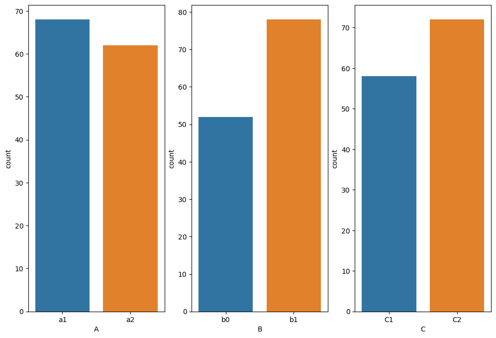

```python
# * Create BAR CHARTS to visually show the counts for the number of rows per unique value for NON-NUMERIC columns
#     * You may use Pandas or Seaborn to create the bar charts
fig, axs=plt.subplots(1,3,figsize=(12,8))
sns.countplot(data=df01, x='A', ax=axs[0])
sns.countplot(data=df01, x='B', ax=axs[1])
sns.countplot(data=df01, x='C', ax=axs[2])
plt.show()
```

- **IMPORTANT:** After creating BAR CHARTS and HISTOGRAMS answer the following:
  - Do the categories of the NON-NUMERIC columns have similar counts?
  - Do the histograms of the NUMERIC columns look roughly like bell curves?

No they don't have similar counts. In terms of counts, a1> a2, b0< b1, c1<c2.

```python
%%capture # This one is to have the output not printed
sns.catplot(data=df01, x='A', kind='count');
sns.catplot(data=df01, x='B', kind="count");
sns.catplot(data=df01, x='C', kind='count');
plt.show();
```

```
UsageError: unrecognized arguments: This one is to have the output not printed
```

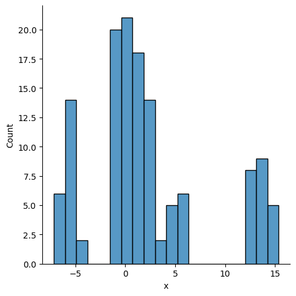

```python
# * Create HISTOGRAMS to visually show the DISTRIBUTION of NUMERIC columns
#     * You may use Pandas or Seaborn to create the histogram
# * **IMPORTANT:** You **MUST** visually explore the counts of NUMERIC columns
# that have less than 20 unique values as if they are NON-NUMERIC columns

sns.displot(data=df01, x='x', kind='hist', bins=20)
```

It does not look like a bell curve. Specifically it has 3 distinct modes but normal distribution has a single mode.

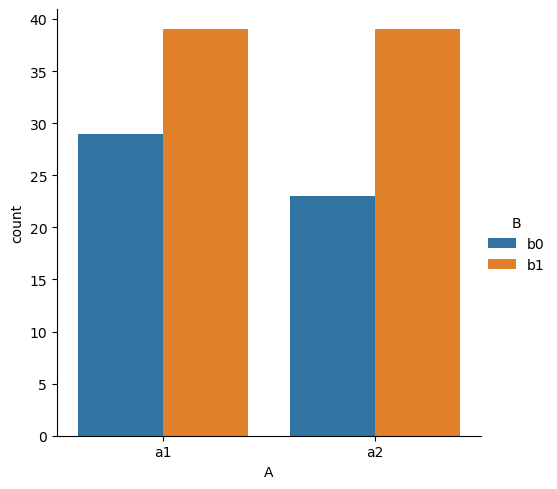

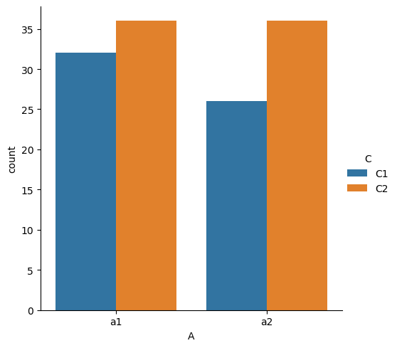

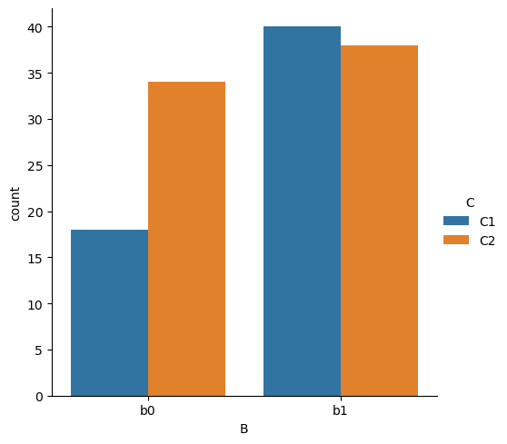

```python
# For each of the 3 assigned data sets you must create plots/figures/charts to explore **combinations**
# between 2 NON-NUMERIC columns. You must therefore perform the following tasks:

# * Create DODGED bar charts to visually show the COUNTS for COMBINATIONS between 2 NON-NUMERIC columns
#     * You **MUST** create the DODGED bar chart using Seaborn

sns.catplot(data=df01, x='A', hue='B', kind='count')
sns.catplot(data=df01, x='A', hue='C', kind='count')
sns.catplot(data=df01, x='B', hue='C', kind='count')

plt.show()
```

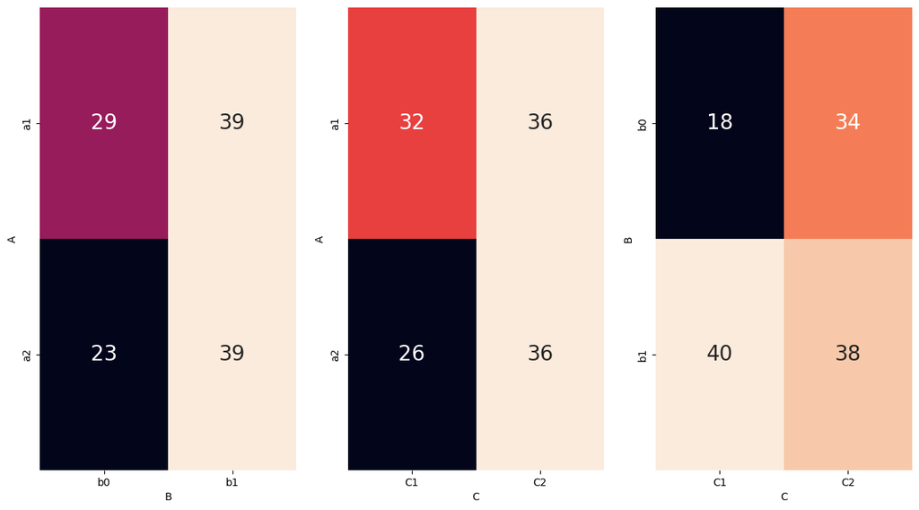

```python
# * Create HEAT MAPS to visually show the COUNTS for COMBINATIONS between 2 NON-NUMERIC columns
#     * You **MUST** create the HEAT MAP using Seaborn
#     * The HEAT MAP **MUST** be annotated with count displayed as TEXT
# * **IMPORTANT:** You **MUST** treat NUMERIC columns that have less than 20 unique values as
# if they are NON-NUMERIC columns

fig, axs= plt.subplots(1,3, figsize=(15,8))

sns.heatmap(pd.crosstab(df01.A, df01.B), ax=axs[0], annot=True, annot_kws={'size':20},\
    fmt='d', cbar=False)
sns.heatmap(pd.crosstab(df01.A, df01.C), ax=axs[1], annot=True, annot_kws={'size': 20},\
    fmt='d', cbar=False)
sns.heatmap(pd.crosstab(df01.B, df01.C), ax=axs[2], annot=True, annot_kws={'size': 20},\
    fmt='d', cbar=False)
plt.show()
```

- **IMPORTANT:** After creating the DODGED bar charts and HEAT MAPS answer the following:
  - Are there combinations between the 2 variables NOT present in the data?
  - Which plot type was it easier to identify combinations that were NOT present?

No, there is no combination between the 2 variables NOT present in the data. Both ways are equally helpful. Heatmap slightly better.

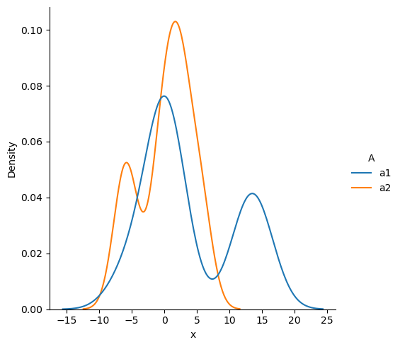

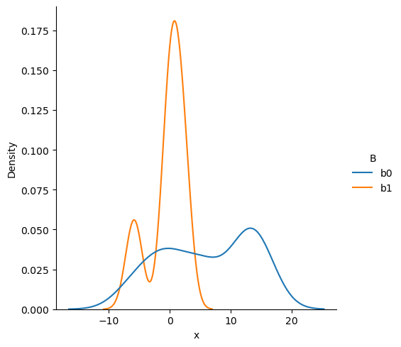

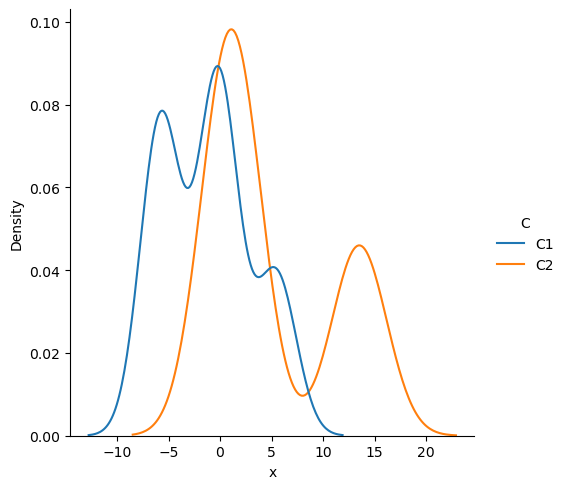

```python
# For each of the 3 assigned data sets you must create plots/figures/charts
# to explore **relationships** between CATEGORICAL and CONTINUOUS variables.
# You must therefore explore the relationship between 1 NON-NUMERIC column and 1 NUMERIC column.
# You must perform the following tasks:

# * Create CONDITIONAL KDE plots to show the conditional distribution of the NUMERIC column
# CONDITIONED ON (or GROUPED BY) the NON-NUMERIC column
#     * You **MUST** create the CONDITIONAL KDE plot using Seaborn with the
#       NON-NUMERIC column associated with the KDE COLOR
#     * You **MUST** remove the SAMPLE SIZE issue with the CONDITIONAL KDE plot

sns.displot(data=df01, x='x', hue='A', kind='kde', common_norm=False)
sns.displot(data=df01, x='x', hue='B', kind='kde', common_norm=False)
sns.displot(data=df01, x='x', hue='C', kind='kde', common_norm=False)


plt.show()
```

- **IMPORTANT:** After creating the figures you must answer the following:
  - Does the distributional SHAPE of a NUMERIC column appear to be different across the CATEGORIES of the NON-NUMERIC column?

Yes, they all are different. E.g.,

in x grouped by A, there is a pick/mode(I don't know using the word mode is a good choice or not because the graph is a distribution function. I think, pick is safer choice of word)/concentration centered around 15 for a1 but a2 doesnot. In particular, a2 is much shifted to the left;

in x grouped by B, domain of b1 is approx in the interval (-10,7). In particular, but b0 is much spreaded out;

in x grouped by C, there is a mode/concentration centered around 15 for C2 but C1 doesnot. In particular, C1 is much shifted to the left.

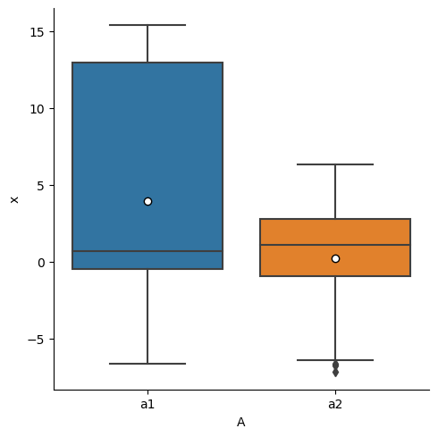

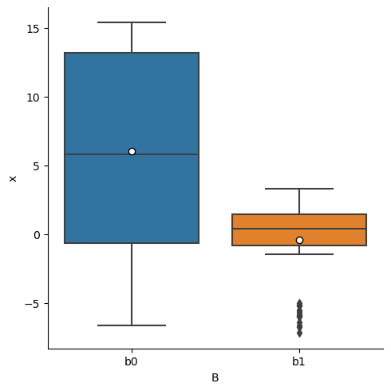

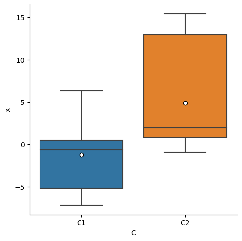

```python
# * Create BOXPLOTS to show if the SUMMARY STATISTICS of the NUMERIC column
#   CHANGE across the CATEGORIES of the NON-NUMERIC column
#     * You **MUST** create the BOXPLOT using Seaborn

sns.catplot(data=df01, x='A', y='x', kind='box', showmeans=True,\
    meanprops={'marker':'o', 'markerfacecolor': 'white', 'markeredgecolor': 'black'} )
sns.catplot(data=df01, x='B', y='x', kind='box', showmeans=True,\
    meanprops={'marker':'o', 'markerfacecolor': 'white', 'markeredgecolor': 'black'} )
sns.catplot(data=df01, x='C', y='x', kind='box', showmeans=True,\
    meanprops={'marker':'o', 'markerfacecolor': 'white', 'markeredgecolor': 'black'} )

plt.show()
```

- Does the MEDIAN of the NUMERIC column appear to be different across the CATEGORIES

  ```
  of the NON-NUMERIC column?
  ```

- Does the VARIATION of the NUMERIC column appear to be different across the CATEGORIES

  ```
  of the NON-NUMERIC column?
  ```

Median of x across A are close enough.

Median of x across B are different.

Median of x across C are not only different but also they are focused/centered around two diffrent region.

The variation of x in a1 is much wider than in a2.

The variation of x in b0 is much wider than in b1.

The variation of x in C2 is much wider than in C1.

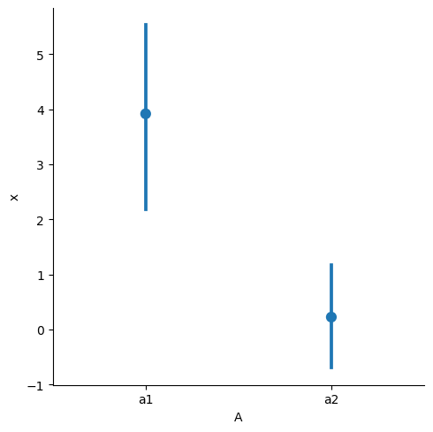

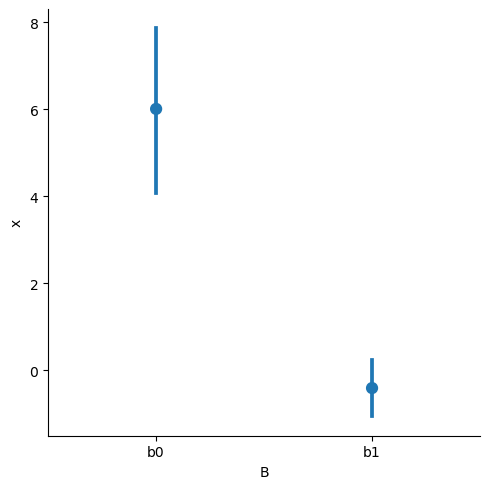

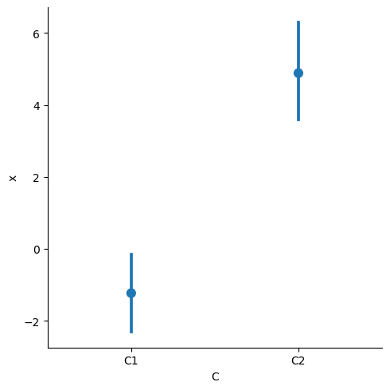

```python
# * Create POINT PLOTS to show if the CONDITIONAL MEAN of the NUMERIC columns
#   CHANGE across the CATEGORIES of the NON-NUMERIC column
#     * You **MUST** create the POINT PLOT using Seaborn
# * **IMPORTANT:** You **MUST** treat NUMERIC columns that have less than 20 unique
#     values as if they are NON-NUMERIC columns

sns.catplot(data=df01, x='A', y='x', kind='point', join=False)
sns.catplot(data=df01, x='B', y='x', kind='point', join=False)
sns.catplot(data=df01, x='C', y='x', kind='point', join=False)
```

- Are you confident that the MEAN of the NUMERIC column CHANGES across the CATEGORIES

  ```
   of the NON-NUMERIC column?
  ```

I am 95% confident in all the cases that the mean changes across all the categories because the CI in t-distribution are disjoint in A,B,C.

## Problem 02

Read in the `hw05_prob_02.csv` CSV file and assign it to the `df02` object.

Visually explore the `df02` object following **ALL** required actions listed previously.

You must add more code cells and markdown cells to complete this problem.

#### 02) - SOLUTION

```python
###
df02=pd.read_csv("hw05_prob_02.csv")
```

```python
df02.info()
```

```
<class 'pandas.core.frame.DataFrame'>
RangeIndex: 368 entries, 0 to 367
Data columns (total 4 columns):
 #   Column  Non-Null Count  Dtype
---  ------  --------------  -----
 0   x       368 non-null    float64
 1   y       352 non-null    float64
 2   A       347 non-null    float64
 3   G       368 non-null    int64
dtypes: float64(3), int64(1)
memory usage: 11.6 KB
```

```python
df02.isna().sum()
```

```
x     0
y    16
A    21
G     0
dtype: int64
```

```python
df02.nunique()
```

```
x    368
y    352
A      2
G     14
dtype: int64
```

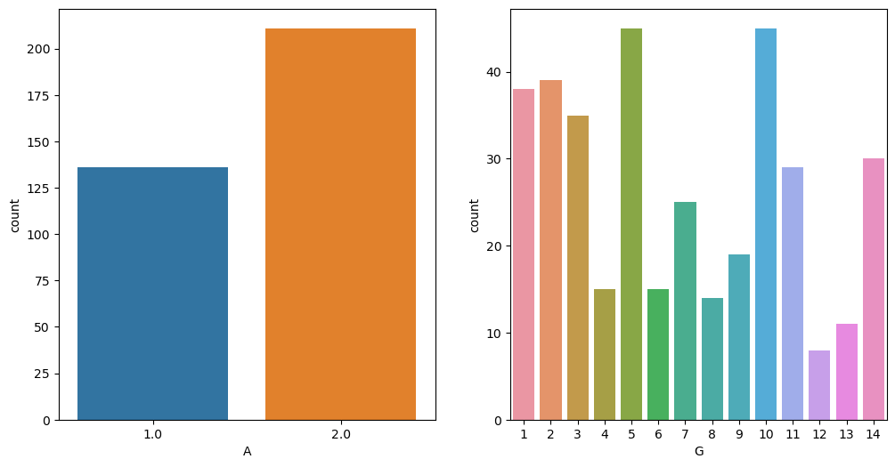

```python
# * Create BAR CHARTS to visually show the counts for the number of rows per unique value for NON-NUMERIC columns
#     * You may use Pandas or Seaborn to create the bar charts

fig, axs= plt.subplots(1,2, figsize=(12,6))

sns.countplot(data=df02, x='A', ax=axs[0])
sns.countplot(data=df02, x='G', ax=axs[1])
plt.show()
```

- **IMPORTANT:** After creating BAR CHARTS and HISTOGRAMS answer the following:
  - Do the categories of the NON-NUMERIC columns have similar counts?
  - Do the histograms of the NUMERIC columns look roughly like bell curves?

No they don't have similar counts. We have higher count for 2 than 1 for A. For G all the 14 categories have uneven counts.

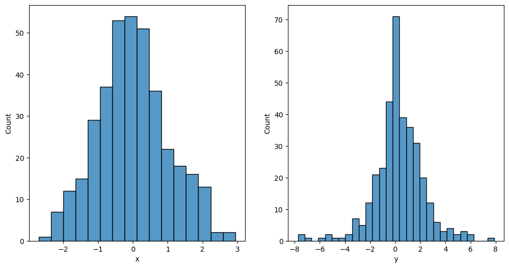

```python
# * Create HISTOGRAMS to visually show the DISTRIBUTION of NUMERIC columns
#     * You may use Pandas or Seaborn to create the histogram
# * **IMPORTANT:** You **MUST** visually explore the counts of NUMERIC columns
# that have less than 20 unique values as if they are NON-NUMERIC columns

fig, axs= plt.subplots(1,2, figsize=(12,6))

sns.histplot(data=df02, x='x', ax=axs[0])
sns.histplot(data=df02, x='y', ax=axs[1])
plt.show()
```

Yes, it looks like a bell curve for both of them.

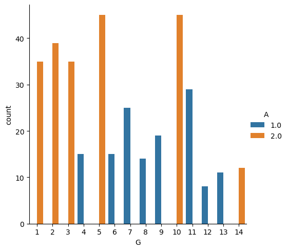

```python
# For each of the 3 assigned data sets you must create plots/figures/charts to explore **combinations**
# between 2 NON-NUMERIC columns. You must therefore perform the following tasks:

# * Create DODGED bar charts to visually show the COUNTS for COMBINATIONS between 2 NON-NUMERIC columns
#     * You **MUST** create the DODGED bar chart using Seaborn

sns.catplot(data=df02, x='G', hue='A', kind='count')

plt.show()
```

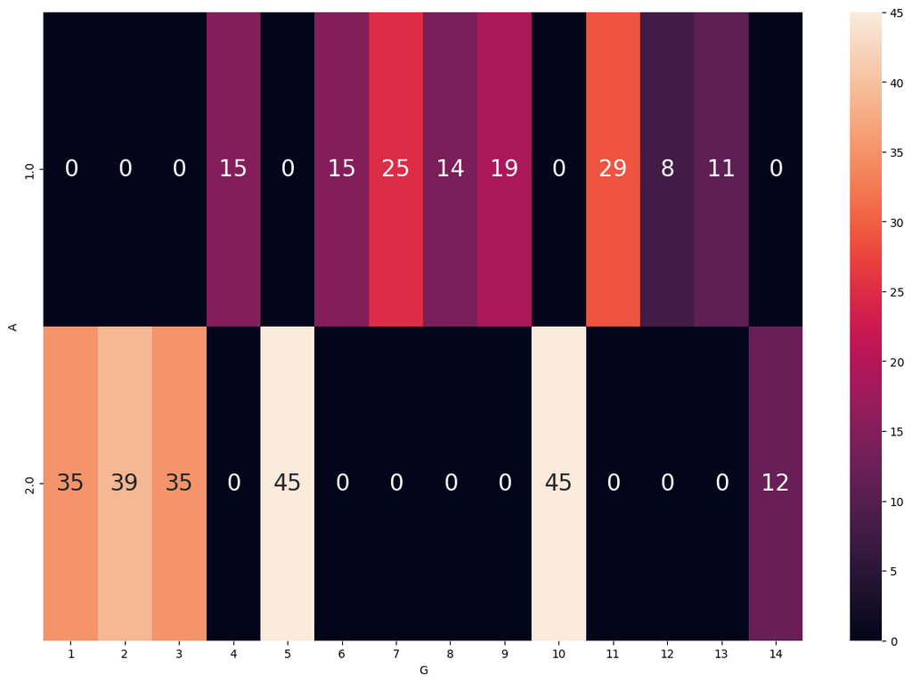

```python
fig, ax= plt.subplots(figsize=(15,10))

sns.heatmap(pd.crosstab(df02.A,df02.G), ax=ax, annot=True, annot_kws={'size': 20}, fmt='d',\
    cbar=True)
```

- **IMPORTANT:** After creating the DODGED bar charts and HEAT MAPS answer the following:
  - Are there combinations between the 2 variables NOT present in the data?
  - Which plot type was it easier to identify combinations that were NOT present?

Yes, there are combinations where both of them were not present e.g., (G,A)=(1,1),(2,1),(3,1),(5,1),(10,1),(14,1) and (G,A) where A=2 and G=4,6,7,8,9,11,12,13. Hands on the heat map was easier.

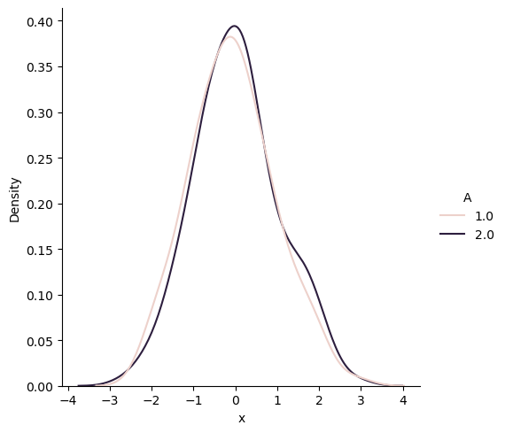

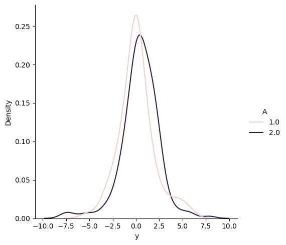

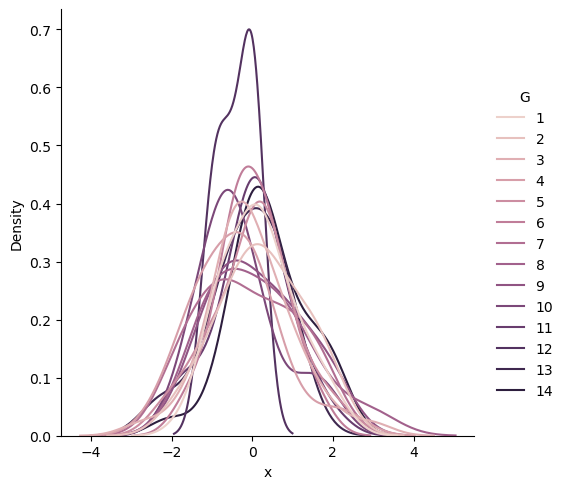

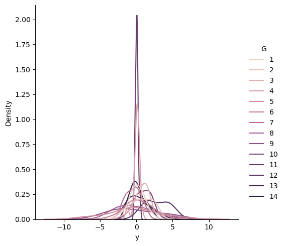

```python
# For each of the 3 assigned data sets you must create plots/figures/charts
# to explore **relationships** between CATEGORICAL and CONTINUOUS variables.
# You must therefore explore the relationship between 1 NON-NUMERIC column and 1 NUMERIC column.
# You must perform the following tasks:

# * Create CONDITIONAL KDE plots to show the conditional distribution of the NUMERIC column
# CONDITIONED ON (or GROUPED BY) the NON-NUMERIC column
#     * You **MUST** create the CONDITIONAL KDE plot using Seaborn with the
#       NON-NUMERIC column associated with the KDE COLOR
#     * You **MUST** remove the SAMPLE SIZE issue with the CONDITIONAL KDE plot

sns.displot(data=df02, x='x', hue='A', kind='kde', common_norm=False)
sns.displot(data=df02, x='y', hue='A', kind='kde', common_norm=False)
sns.displot(data=df02, x='x', hue='G', kind='kde', common_norm=False)
sns.displot(data=df02, x='y', hue='G', kind='kde', common_norm=False)

plt.show()
```

- **IMPORTANT:** After creating the figures you must answer the following:
  - Does the distributional SHAPE of a NUMERIC column appear to be different across the CATEGORIES of the NON-NUMERIC column?

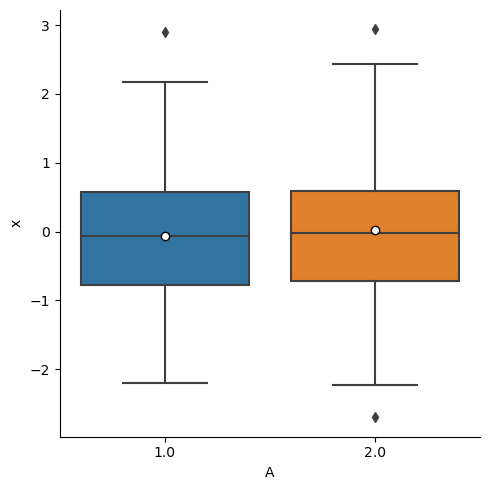

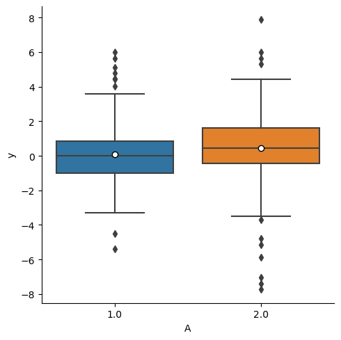

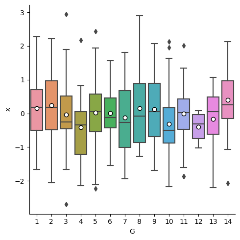

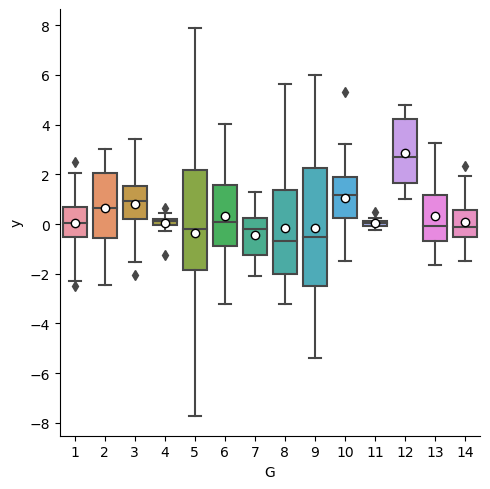

```python
# * Create BOXPLOTS to show if the SUMMARY STATISTICS of the NUMERIC column
#   CHANGE across the CATEGORIES of the NON-NUMERIC column
#     * You **MUST** create the BOXPLOT using Seaborn

sns.catplot(data=df02, x='A', y='x', kind='box', showmeans=True,\
    meanprops={'marker':'o', 'markerfacecolor': 'white', 'markeredgecolor': 'black'} )
sns.catplot(data=df02, x='A', y='y', kind='box', showmeans=True,\
    meanprops={'marker':'o', 'markerfacecolor': 'white', 'markeredgecolor': 'black'} )
sns.catplot(data=df02, x='G', y='x', kind='box', showmeans=True,\
    meanprops={'marker':'o', 'markerfacecolor': 'white', 'markeredgecolor': 'black'} )
sns.catplot(data=df02, x='G', y='y', kind='box', showmeans=True,\
    meanprops={'marker':'o', 'markerfacecolor': 'white', 'markeredgecolor': 'black'} )

plt.show()
```

- Does the MEDIAN of the NUMERIC column appear to be different across the CATEGORIES

  ```
  of the NON-NUMERIC column?
  ```

- Does the VARIATION of the NUMERIC column appear to be different across the CATEGORIES

  ```
  of the NON-NUMERIC column?
  ```

For G and y we can see that medians fluctuate but the variation of numeric columns have some common region except G-12 which stands out of the crowd and have almost no common region in the 50% box data with others. We can conclude that for G-12 the values in y starts greater than zero and more than 50% data is bigger than y=2 with mean, median greater than 2. Numeric column varies a lot. There are some columns like G-11 and G-4 which are really centered around 0 with minimum variability. On the other hand G-5 and G-9 with larger variability.

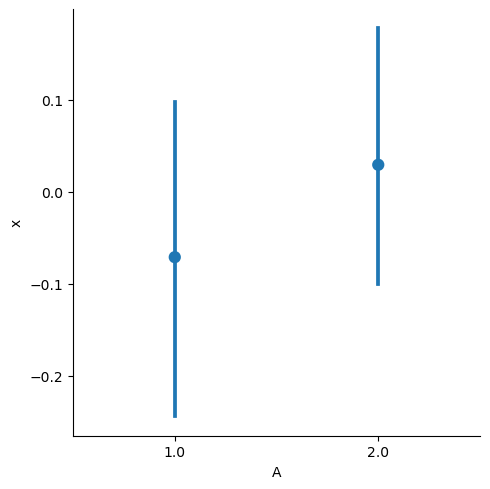

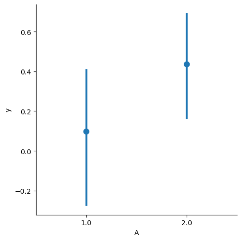

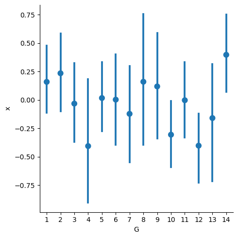

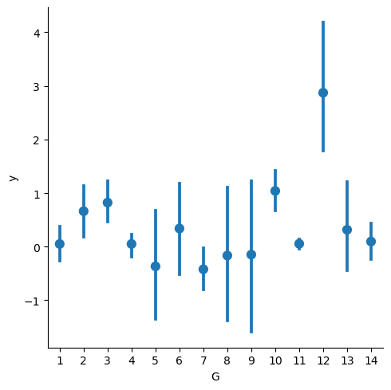

```python
# * Create POINT PLOTS to show if the CONDITIONAL MEAN of the NUMERIC columns
#   CHANGE across the CATEGORIES of the NON-NUMERIC column
#     * You **MUST** create the POINT PLOT using Seaborn
# * **IMPORTANT:** You **MUST** treat NUMERIC columns that have less than 20 unique
#     values as if they are NON-NUMERIC columns

sns.catplot(data=df02, x='A', y='x', kind='point', join=False)
sns.catplot(data=df02, x='A', y='y', kind='point', join=False)
sns.catplot(data=df02, x='G', y='x', kind='point', join=False)
sns.catplot(data=df02, x='G', y='y', kind='point', join=False)

plt.show()
```

- Are you confident that the MEAN of the NUMERIC column CHANGES across the CATEGORIES

  ```
   of the NON-NUMERIC column?
  ```

Mean is changing based of this sample across the columns but we are not 95% confident about the population mean in (A,x),(A,y) as the CI in the t distribution have intersection.

In (G,x) although the subsequent columns have some intersection but if we go further across rows we won't see overlap e.g., {G=12, G=14} and {G=14, G=10} don't have any overlap hence we are 95% confident that even in the population mean they will be different.

In (G,y) although the subsequent columns might have some intersection but if we go further across rows we won't see overlap e.g., {G=2, G=7}, {G=3, G=4}, {G=3, G=7}, {G=3, G=11}, {G=4, G=10}, {G=7, G=10}, {G-10,G-11}. don't have any overlap hence we are 95% confident that even in the population mean they will be different.

We have also observed in the box plot that the data for G=11 and G=4 is really clustered around 0 in column y with minimum variability.